# Project1

```r
#filling some missing data before prediction
new_df_2015$temp[8734:8736]=new_df_2015$temp[8735]
p_res2015=predict(tr,new_df_2015[,c("hour","month","temp","dewp","day","slp")])
rmse_gbm=sqrt(mean((p_res2015-new_df_2015$kwh)^2))
print("rmse_gbm")
```

```
## [1] "rmse_gbm"
```

```r
rmse_gbm
```

```
## [1] 109.5341
```

```r
mae=mean(abs(p_res2015-new_df_2015$kwh))
print("mean_abs_error_gbm")
```

```
## [1] "mean_abs_error_gbm"
```

```r
mae
```

```
## [1] 84.41904
```

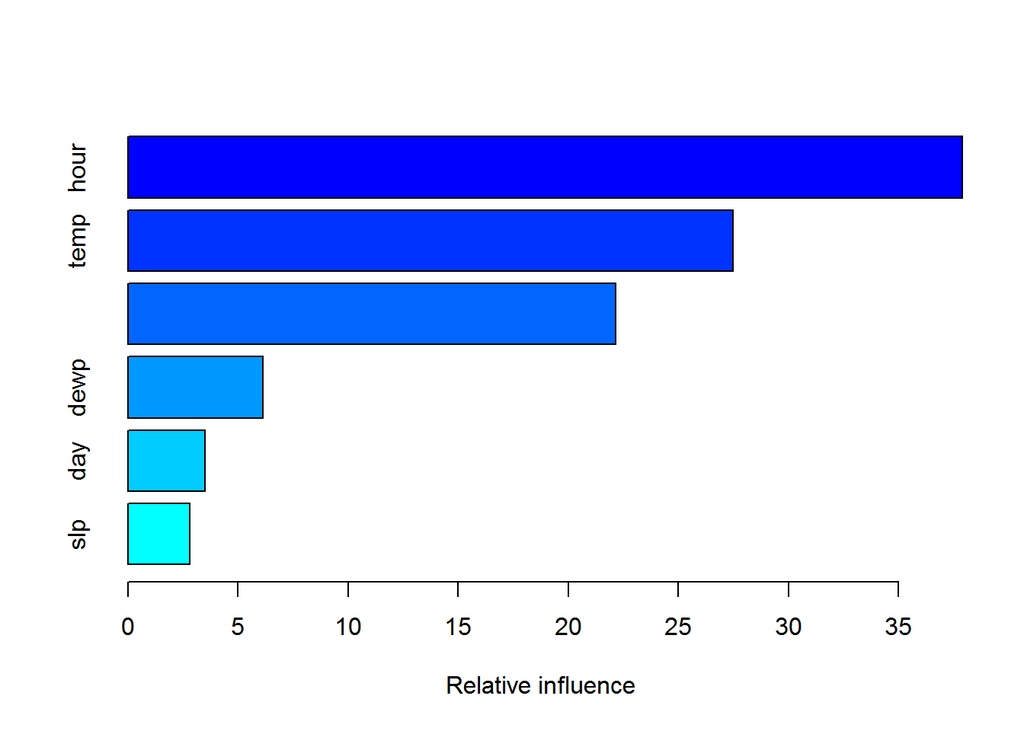

```
##         var   rel.inf
## hour   hour 37.896131
## temp   temp 27.493319
## month month 22.146378
## dewp   dewp  6.133800
## day     day  3.511935
## slp     slp  2.818437
```

```r
summary(tr)
```

Lets now compare the predicted model for 2015 with the bill data kwh!

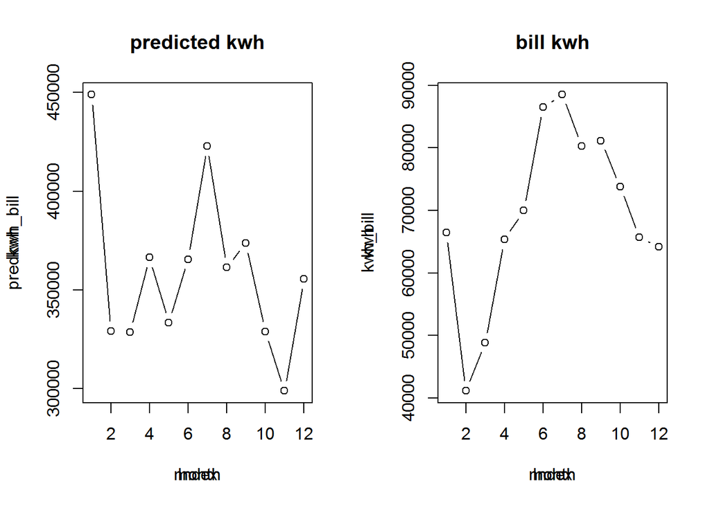

```r
#
# run your machine learning model and create a data frame of dates, kwh for 1hr interval data for 2015. note you
# may need to include the last few days of 2014 in your dataset due to the billing dates in January (see billdata.xlsx)
# call your data frame pred2015df.
# now for each of the 12 rows (billing periods) in the billsdf, sum the kwh for the date range in each of the rows from pred2015df for the corresponding start and end of billing in billsdf
# create a resultsdf which has billdate, predkwh (from pred2015df), actualkwh (from billsdf)
# display the results


startdate=as.Date(as.numeric(as.character(billsdf$billstartdt[-13])), origin='1899-12-30')
enddate=as.Date(as.numeric(as.character(billsdf$billenddt[-13])), origin='1899-12-30')
pred2015df=data.frame(modeldatadf[8473:17496,])
pred2015df$kwh=0
#Using GBM model
fillkwh=predict(tr,pred2015df[c('hour','day','temp')])
pred2015df$kwh=fillkwh
predkwh_bill=rep(0,12)
for(i in 1:12)
{
d1=as.numeric(format(startdate[i],"%d"))
m1=as.numeric(format(startdate[i],"%m"))
y1=as.numeric(format(startdate[i],"%Y"))
d2=as.numeric(format(enddate[i],"%d"))
m2=as.numeric(format(enddate[i],"%m"))
predkwh_bill[i]=sum(pred2015df$kwh[(pred2015df$day>=d1 & pred2015df$month==m1 & pred2015df$year==y1) | (pred2015df$year==2015 & pred2015df$day<=d2 & pred2015df$month==m2) ],na.rm=TRUE)
}
kwh_bill=as.numeric(as.character(billsdf$kwh[1:12]))

# Since bill date is missing for most of the entries, enddate of the bill is taken as bill date
resultsdf = data.frame(startdate,predkwh_bill,kwh_bill)

#displaying result
par(mfrow=c(1,2))
plot(predkwh_bill,type="b")
title(ylab="kwh",xlab="month",main="predicted kwh")
plot(kwh_bill, type="b")
title(ylab="kwh",xlab="month",main="bill kwh")
```

```r
rmse_billkwh=sqrt(mean((kwh_bill-predkwh_bill)^2))
print("The RMSE for bill kwh: ")
```

```
## [1] "The RMSE for bill kwh: "
```

```r
print(rmse_billkwh)
```

```
## [1] 292446.1
```

This completes this little exploration of energy load data. Thank You!

CLUSTERING ASSIGNMENT

YEAR 2014

```r
#2014

spring14 = subset(new_df_2014, month>=3 & month<=5)
summer14 = subset(new_df_2014, month>=6 & month<=8)
fall14 = subset(new_df_2014, month>=9 & month<=11)
winter14 = subset(new_df_2014, month==12 | month<=2)

# TO GET INDEXING STARTING FROM 1 FOR ROWS
rownames(spring14)<-NULL
rownames(summer14)<-NULL
rownames(fall14)<-NULL
rownames(winter14)<-NULL

# BUILDING MATRIX TO GET HEATMAP OF TEMPERATURE
```

METHOD 1: FINDING SPLIT INTERVALS BY PLOT ANALYSIS

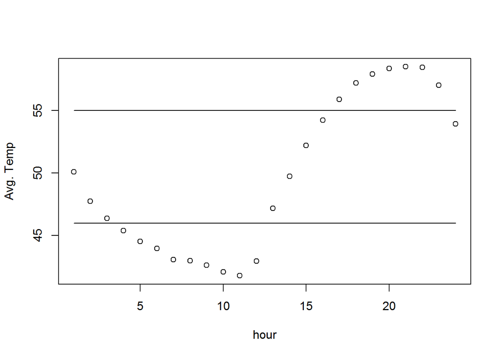

```r
# SPRING SEASON ANALYSIS
temp_spring = aggregate(spring14$temp, by = list(hour=spring14$hour), FUN = mean)
plot(temp_spring,ylab = "Avg. Temp")
lines(1:24,rep(46,24))
lines(1:24,rep(55,24))
```

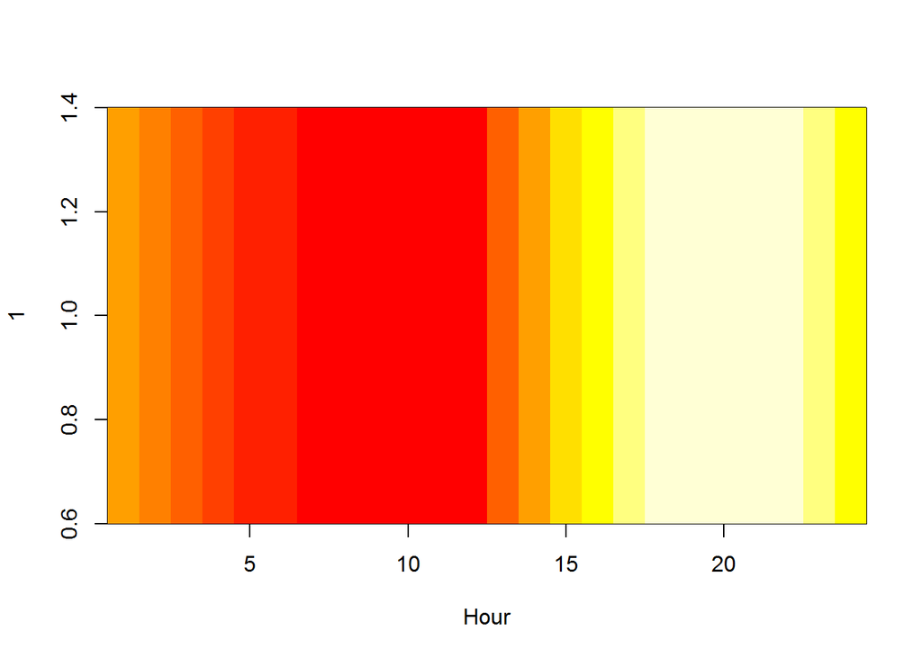

```r
image(1:24,1, matrix(temp_spring[,2]), xlab= "Hour")
```

FROM THE PLOT AND HEATMAP, I CHOOSE MY INTERVALS AS, (1). HOUR 4-12. (2). HOUR 1-3, 13-16, 24. (3). HOUR 17-23

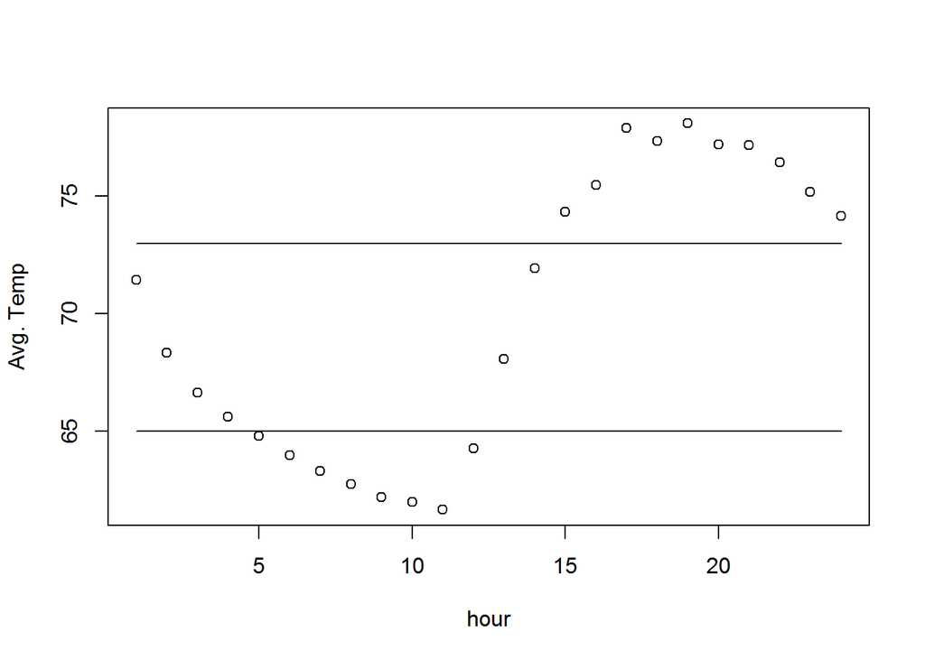

```r
# FROM THE PLOT AND HEATMAP, I CHOOSE MY INTERVALS AS, (1). HOUR 4-12. (2). HOUR 1-3, 13-16, 24. (3). HOUR 17-23
cl14_1 = subset(spring14, hour>=4 & hour<=12)
cl14_2 = subset(spring14, (hour>=1 & hour<=3) | (hour>=13 & hour<=16) | hour==24)
cl14_3 = subset(spring14, hour>=17 & hour<=23)

# SUMMER SEASON ANALYSIS
temp_summer = aggregate(summer14$temp, by = list(hour=summer14$hour), FUN = mean)
plot(temp_summer,ylab = "Avg. Temp")
lines(1:24,rep(65,24))
lines(1:24,rep(73,24))
```

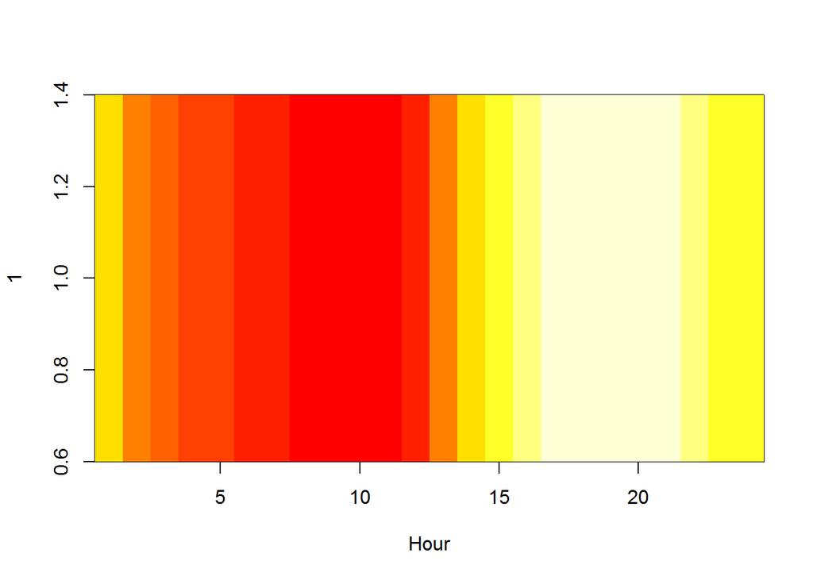

```r
image(1:24,1, matrix(temp_summer[,2]), xlab= "Hour")
```

FROM THE PLOT AND HEATMAP, I CHOOSE MY INTERVALS AS, (1). HOUR 5-12. (2). HOUR 1-4, 13, 14. (3). HOUR 15-24

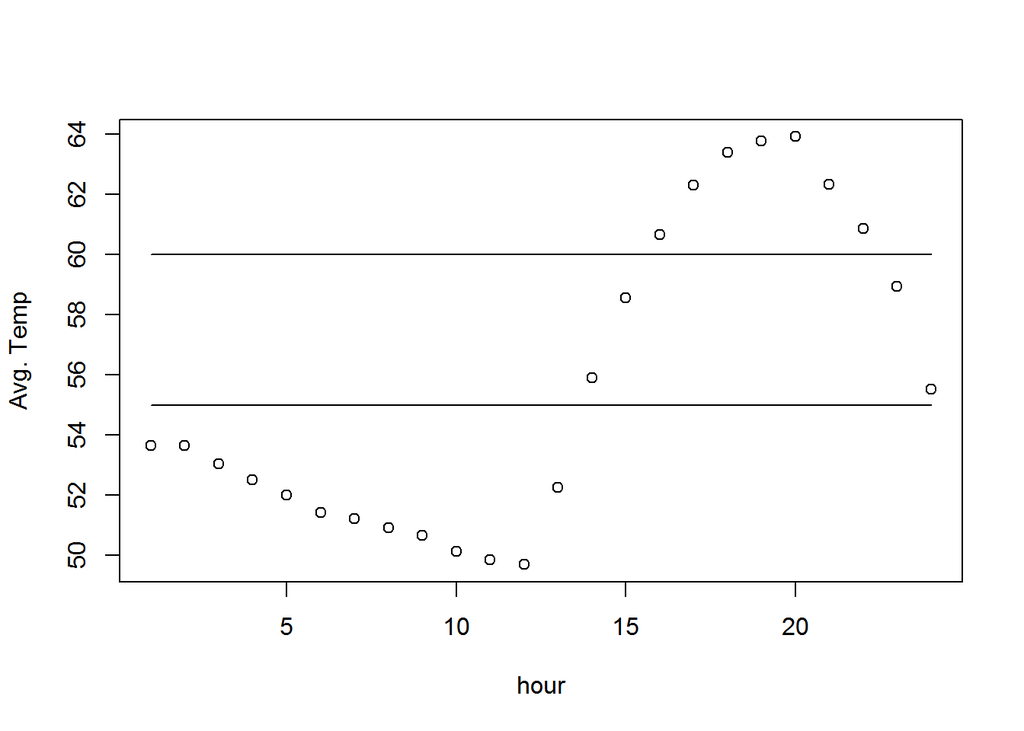

```r
# FROM THE PLOT AND HEATMAP, I CHOOSE MY INTERVALS AS, (1). HOUR 5-12. (2). HOUR 1-4, 13, 14. (3). HOUR 15-24
cl14_4 = subset(summer14, hour>=5 & hour<=12)
cl14_5 = subset(summer14, (hour>=1 & hour<=4) | hour==13 | hour==14)
cl14_6 = subset(summer14, hour>=15 & hour<=24)

# FALL SEASON ANALYSIS
temp_fall = aggregate(fall14$temp, by = list(hour=fall14$hour), FUN = mean)
plot(temp_fall,ylab = "Avg. Temp")
lines(1:24,rep(55,24))
lines(1:24,rep(60,24))
```

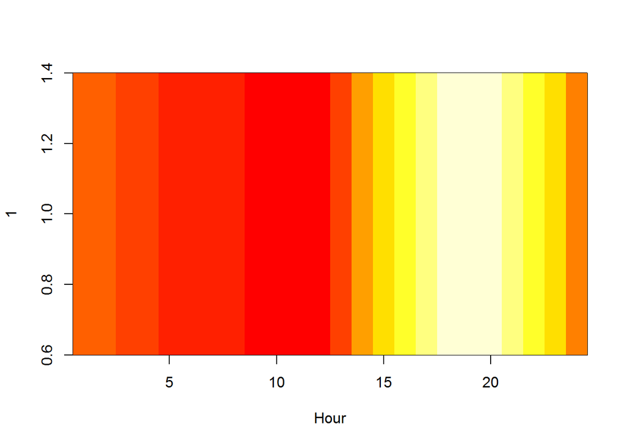

```r
image(1:24,1, matrix(temp_fall[,2]), xlab= "Hour")
```

FROM THE PLOT AND HEATMAP, I CHOOSE MY INTERVALS AS, (1). HOUR 1-13. (2). HOUR 14, 15, 23, 24. (3). HOUR 16-22

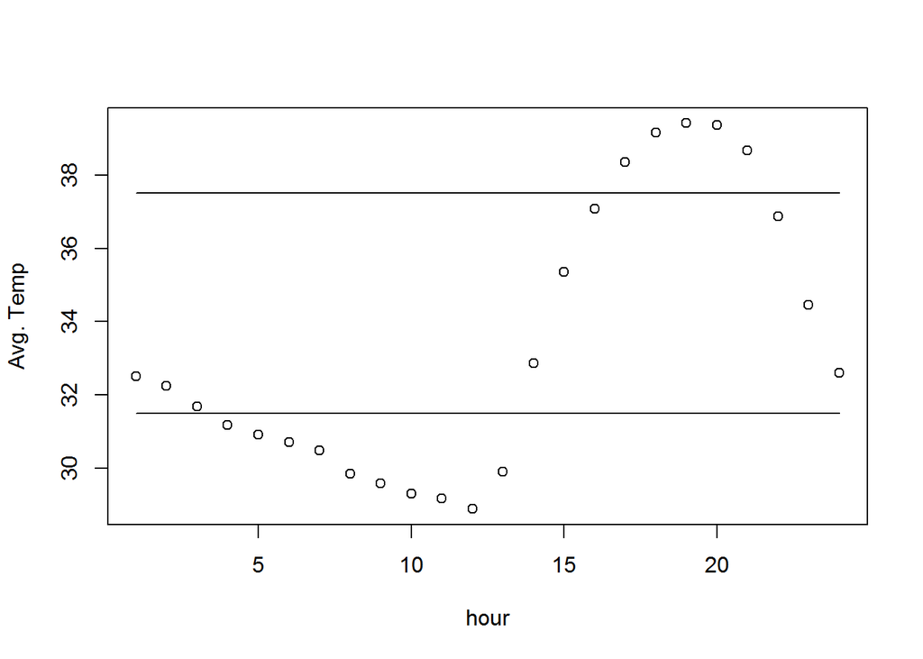

```r
# FROM THE PLOT AND HEATMAP, I CHOOSE MY INTERVALS AS, (1). HOUR 1-13. (2). HOUR 14, 15, 23, 24. (3). HOUR 16-22
cl14_7 = subset(fall14, hour>=1 & hour<=13)
cl14_8 = subset(fall14, hour==14 | hour<=15 | hour==23 | hour==24)
cl14_9 = subset(fall14, hour>=16 & hour<=22)

# WINTER SEASON ANALYSIS
temp_winter = aggregate(winter14$temp, by = list(hour=winter14$hour), FUN = mean)
plot(temp_winter,ylab = "Avg. Temp")
lines(1:24,rep(31.5,24))
lines(1:24,rep(37.5,24))
```

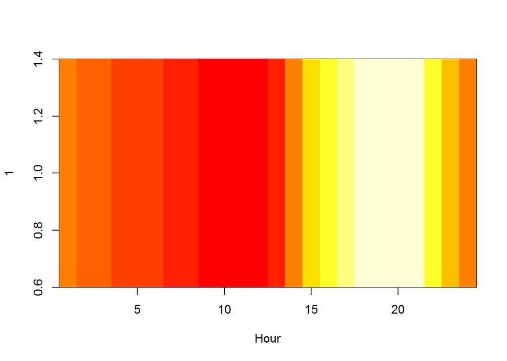

```r
image(1:24,1, matrix(temp_winter[,2]), xlab= "Hour")
```

FROM THE PLOT AND HEATMAP, I CHOOSE MY INTERVALS AS, (1). HOUR 4-13. (2). HOUR 1-3, 14-16, 22-24. (3). HOUR 17-21.

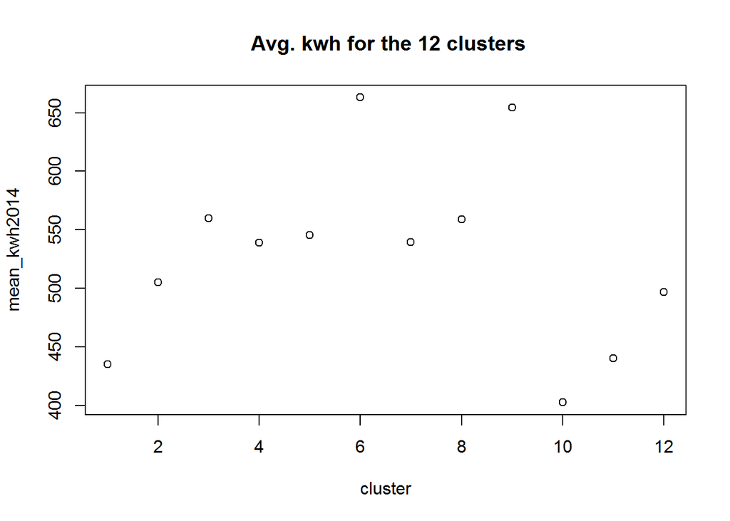

```r
# FROM THE PLOT AND HEATMAP, I CHOOSE MY INTERVALS AS, (1). HOUR 4-13. (2). HOUR 1-3, 14-16, 22-24. (3). HOUR 17-21.
cl14_10 = subset(winter14, hour>=4 & hour<=13)
cl14_11 = subset(winter14, (hour>=1 & hour<=3) | (hour>=14 & hour<=16) | (hour>=22 & hour<=24))
cl14_12 = subset(winter14, hour>=17 & hour<=21)

mean_kwh2014 = c(mean(cl14_1$kwh), mean(cl14_2$kwh), mean(cl14_3$kwh), mean(cl14_4$kwh), mean(cl14_5$kwh), mean(cl14_6$kwh), mean(cl14_7$kwh), mean(cl14_8$kwh), mean(cl14_9$kwh), mean(cl14_10$kwh), mean(cl14_11$kwh), mean(cl14_12$kwh))

plot(mean_kwh2014, xlab = 'cluster', main = ' Avg. kwh for the 12 clusters')
```

An analysis for this result can be demonstrated by the following plot

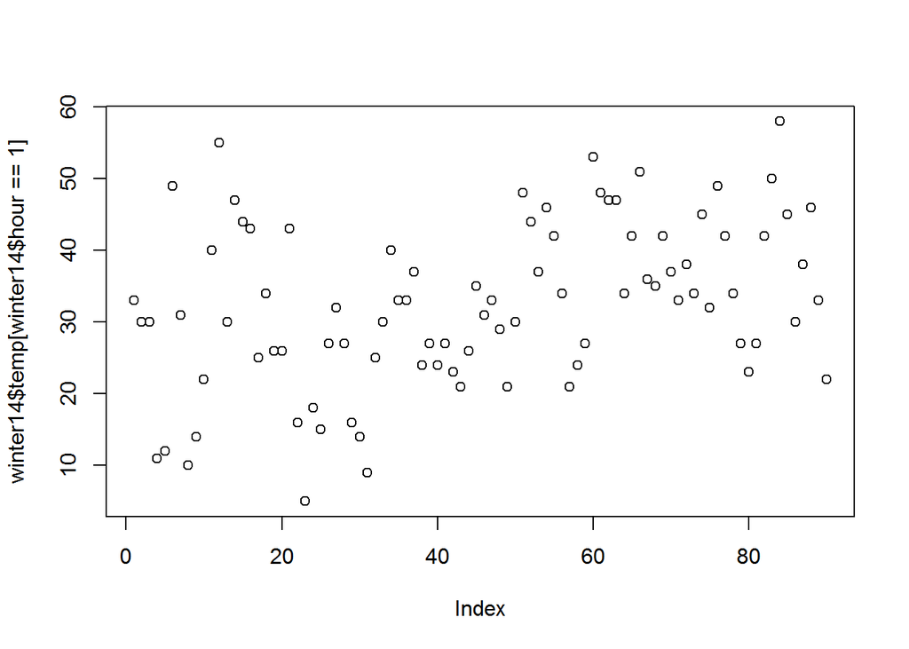

```r
plot(winter14$temp[winter14$hour==1])
```

This plot shows the variation of temperature for hour 1 in one season. It ranges between 5-58 degrees. Therefore clustering this way may not give significant distinction for each season based on average temperature.

METHOD 2: USING K MEANS FOR CLUSTERING EACH SEASON INTO THE THREE TIME INTERVALS

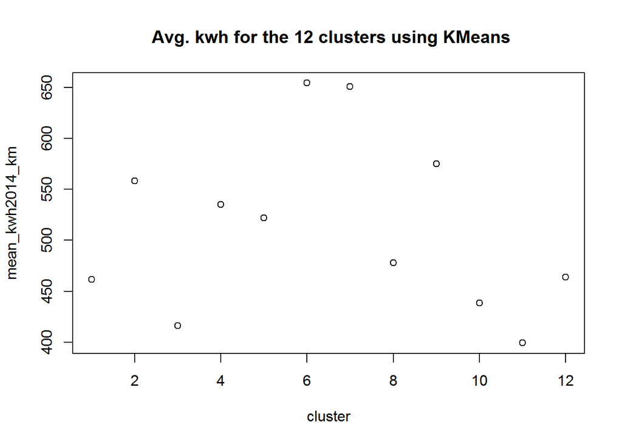

```r
##### METHOD 2: USING K MEANS FOR CLUSTERING EACH SEASON INTO THE THREE TIME INTERVALS

# SPRING
kmSPR = kmeans(spring14$temp, 3, iter.max = 30)
spr1_km = spring14$kwh[kmSPR$cluster==1]
spr2_km = spring14$kwh[kmSPR$cluster==2]
spr3_km = spring14$kwh[kmSPR$cluster==3]

# SUMMER
kmSUM = kmeans(summer14$temp, 3, iter.max = 30)
sum1_km = summer14$kwh[kmSUM$cluster==1]
sum2_km = summer14$kwh[kmSUM$cluster==2]
sum3_km = summer14$kwh[kmSUM$cluster==3]

# FALL
kmFAL = kmeans(fall14$temp, 3, iter.max = 30)
fal1_km = fall14$kwh[kmFAL$cluster==1]
fal2_km = fall14$kwh[kmFAL$cluster==2]
fal3_km = fall14$kwh[kmFAL$cluster==3]

# WINTER
kmWIN = kmeans(winter14$temp, 3, iter.max = 30)
win1_km = winter14$kwh[kmWIN$cluster==1]
win2_km = winter14$kwh[kmWIN$cluster==2]
win3_km = winter14$kwh[kmWIN$cluster==3]

mean_kwh2014_km = c(mean(spr1_km), mean(spr2_km), mean(spr3_km), mean(sum1_km), mean(sum2_km), mean(sum3_km), mean(fal1_km), mean(fal2_km), mean(fal3_km), mean(win1_km), mean(win2_km), mean(win3_km))
plot(mean_kwh2014_km, xlab = 'cluster', main = ' Avg. kwh for the 12 clusters using KMeans')
```

As seen in this plot, the variation in average kwh per cluster is better than previously seen, however, still many clashes in cluster allotment would occur because different clusters for different seasons have some overlapping values. To view this more quantitatively, lets run knn and random forest classifier and find out the 5 fold cross validation accuracy.

```r
TR_DATA = c(spr1_km, spr2_km, spr3_km, sum1_km, sum2_km, sum3_km, fal1_km, fal2_km, fal3_km, win1_km, win2_km, win3_km)
TR_OUT = c(rep(1, length(spr1_km)), rep(2, length(spr2_km)), rep(3, length(spr3_km)), rep(4, length(sum1_km)), rep(5, length(sum2_km)), rep(6, length(sum3_km)), rep(7, length(fal1_km)), rep(8, length(fal2_km)), rep(9, length(fal3_km)), rep(10, length(win1_km)), rep(11, length(win2_km)), rep(12, length(win3_km)))
library(KODAMA)
res = KNN.CV(matrix(TR_DATA), (TR_OUT), 1:length(TR_OUT),5)

table(res,TR_OUT)
```

```
##     TR_OUT
## res    1   2   3   4   5   6   7   8   9  10  11  12
##   1  137 100  55 111   3  62  36  45  66  77  43  94
##   2  119 213  26 161  13 113 108  59 106  45  21  48
##   3   49  32  36  24   0  11  16  17  16  46  39  23
##   4  114 168  37 211  13 134 105  77 107  66  46  64
##   5    3   1   2   8   2   4   7   2   4   4   2   1
##   6   56 132  17 140   5 335 241  19 132  27  20  15
##   7   31  92  21 114   8 229 202  38 115  31  18  27
##   8   32  30  15  43   2  12   8  28  24  44  16  47
##   9   63  73  24  90   4  93 104  19  72  64  31  33
##   10 110  44  83  73  10  29  46  80  79 319 138 152
##   11  44  17  52  29   3  21  20  19  31 129 123  42
##   12  96  46  36  67   4  27  36  56  46 119  44 102
```

```r
print("ACCURACY FOR KNN:")
```

```
## [1] "ACCURACY FOR KNN:"
```

```r
print(length(which(TR_OUT==as.numeric(res)))/length(TR_OUT))
```

```
## [1] 0.2031963
```

The prediction accuracy is around ~20-21%. Depending on application, this maybe a good enough value. For instance, if we have a group of kwh values which we know would belong to a particular cluster, we can look for maximum overlap in prediction. for example, lets take cluster no. 2.

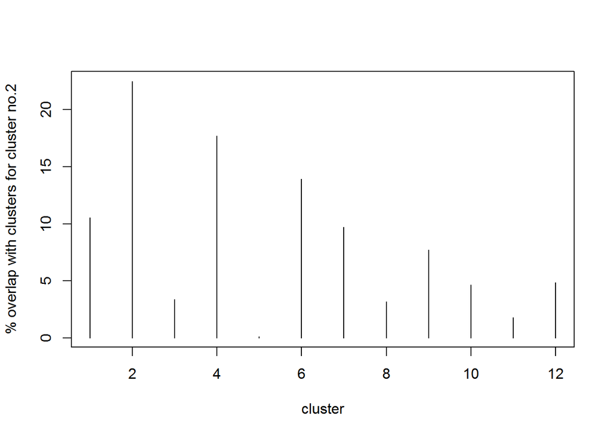

```r
commlocs = {}
locsreal = which(TR_OUT==2)
for(i in 1:12){
locspred = which(as.numeric(res)==i)
commlocs[i] = 100*length(intersect(locsreal,locspred))/length(locsreal)
}

plot(commlocs, type="h", xlab="cluster", ylab="% overlap with clusters for cluster no.2")
```

```r
#
```

As we can see, maximum overlap is with cluster 2

```r
#random forest
library(randomForest)
rf=randomForest(matrix(TR_DATA),factor(TR_OUT))
print("Accuracy for random forest:")
```

```
## [1] "Accuracy for random forest:"
```

```r
print(100*length(which(TR_OUT==as.numeric(rf$predicted)))/length(TR_OUT))
```

```
## [1] 18.1621
```

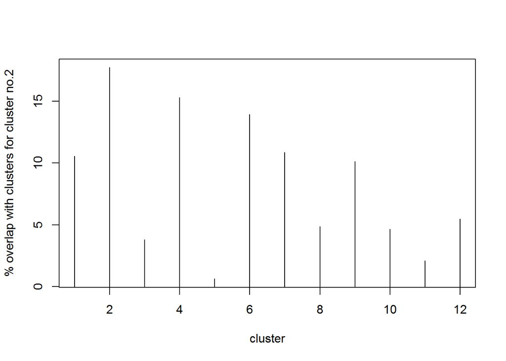

```r
# Accuracy is ~18%. As done previously, lets check for cluster no.2
commlocs = {}
locsreal = which(TR_OUT==2)
for(i in 1:12){
locspred = which(rf$predicted==i)
commlocs[i] = 100*length(intersect(locsreal,locspred))/length(locsreal)
}

plot(commlocs, type="h", xlab="cluster", ylab="% overlap with clusters for cluster no.2")
```

Again, maxmimum no. of point belong to cluster 2 in out predcition. Therefore it could be useful in such applications.

YEAR 2015

```r
#2015

spring15 = subset(new_df_2015, month>=3 & month<=5)
summer15 = subset(new_df_2015, month>=6 & month<=8)
fall15 = subset(new_df_2015, month>=9 & month<=11)
winter15 = subset(new_df_2015, month==12 | month<=2)

# TO GET INDEXING STARTING FROM 1 FOR ROWS
rownames(spring15)<-NULL
rownames(summer15)<-NULL
rownames(fall15)<-NULL
rownames(winter15)<-NULL
```

METHOD 1: SPLIT BY PLOT ANALYSIS

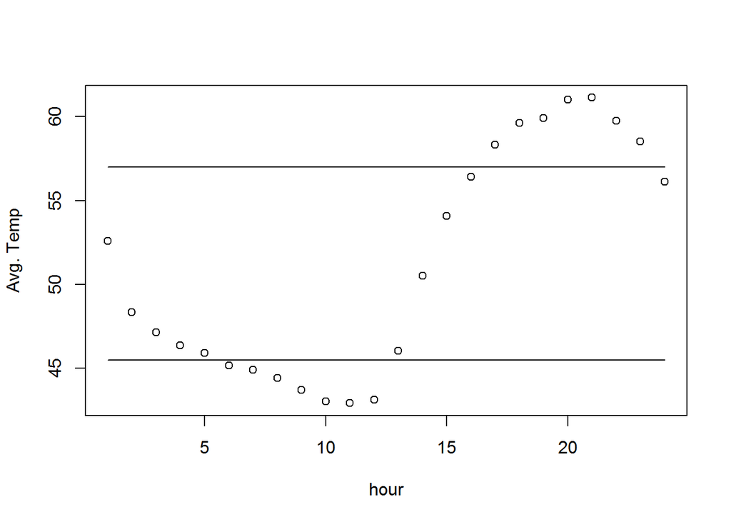

```r
# SPRING SEASON ANALYSIS
temp_spring = aggregate(spring15$temp, by = list(hour=spring15$hour), FUN = mean)
plot(temp_spring,ylab = "Avg. Temp")
lines(1:24,rep(45.5,24))
lines(1:24,rep(57,24))
```

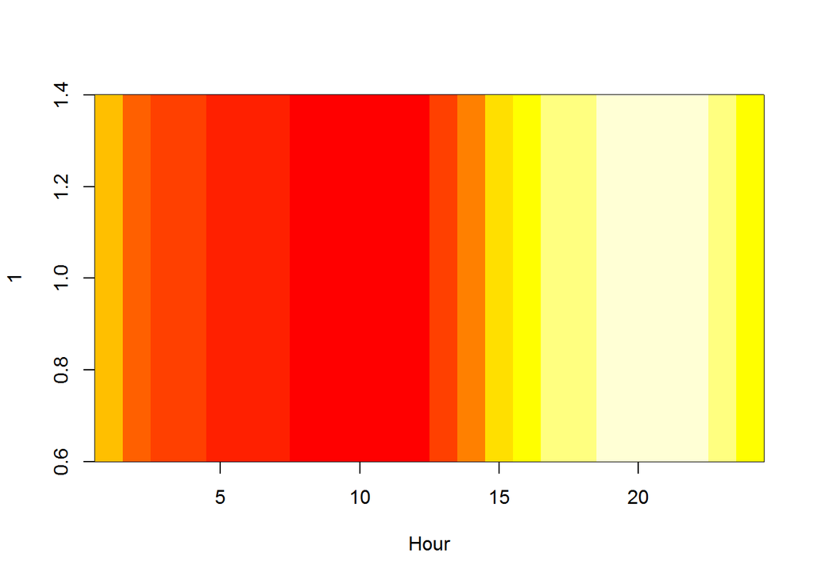

```r
image(1:24,1, matrix(temp_spring[,2]), xlab= "Hour")
```

FROM THE PLOT AND HEATMAP, I CHOOSE MY INTERVALS AS, (1). HOUR 6-12. (2). HOUR 1-5, 13-16, 24. (3). HOUR 17-23

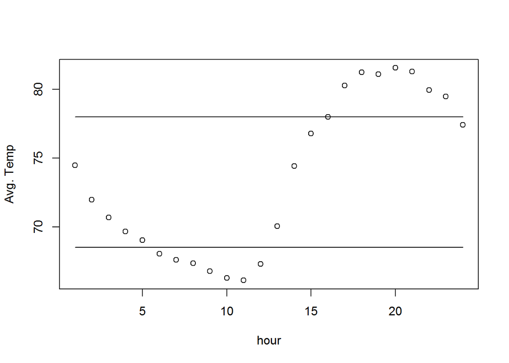

```r
# FROM THE PLOT AND HEATMAP, I CHOOSE MY INTERVALS AS, (1). HOUR 6-12. (2). HOUR 1-5, 13-16, 24. (3). HOUR 17-23
cl15_1 = subset(spring15, hour>=6 & hour<=12)
cl15_2 = subset(spring15, (hour>=1 & hour<=5) | (hour>=13 & hour<=16) | hour==24)
cl15_3 = subset(spring15, hour>=17 & hour<=23)

# SUMMER SEASON ANALYSIS
temp_summer = aggregate(summer15$temp, by = list(hour=summer15$hour), FUN = mean)
plot(temp_summer,ylab = "Avg. Temp")
lines(1:24,rep(68.5,24))
lines(1:24,rep(78,24))
```

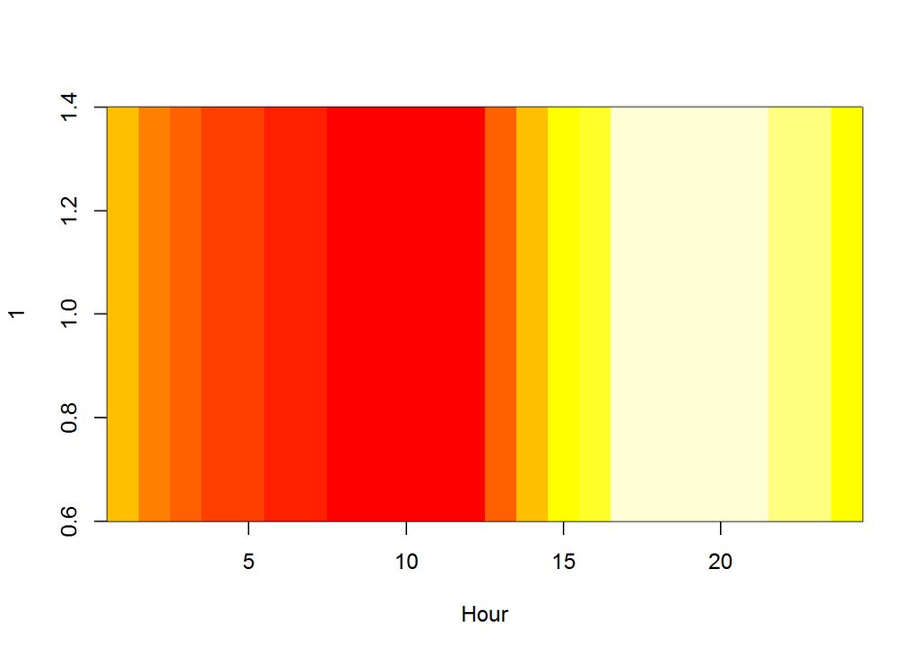

```r
image(1:24,1, matrix(temp_summer[,2]), xlab= "Hour")
```

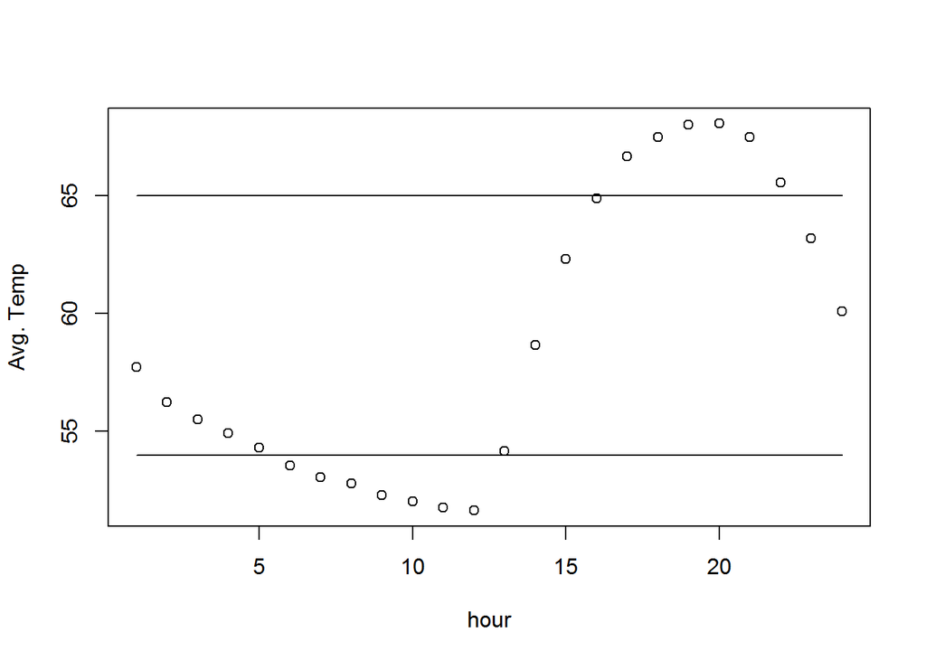

```r
# FROM THE PLOT AND HEATMAP, I CHOOSE MY INTERVALS AS, (1). HOUR 6-12. (2). HOUR 1-5, 13-16, 24. (3). HOUR 17-23
cl15_4 = subset(summer15, hour>=6 & hour<=12)
cl15_5 = subset(summer15, (hour>=1 & hour<=4) | (hour>=13 & hour<=16) | hour==24)
cl15_6 = subset(summer15, hour>=17 & hour<=23)

# FALL SEASON ANALYSIS
temp_fall = aggregate(fall15$temp, by = list(hour=fall15$hour), FUN = mean)
plot(temp_fall,ylab = "Avg. Temp")
lines(1:24,rep(54,24))
lines(1:24,rep(65,24))
```

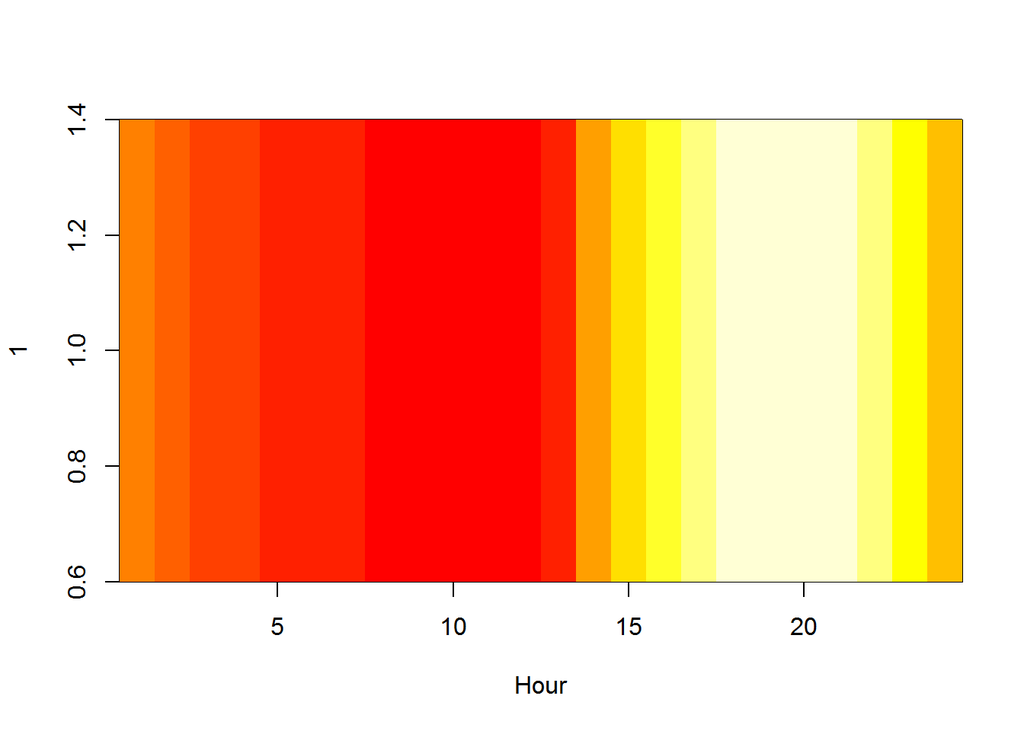

```r
image(1:24,1, matrix(temp_fall[,2]), xlab= "Hour")
```

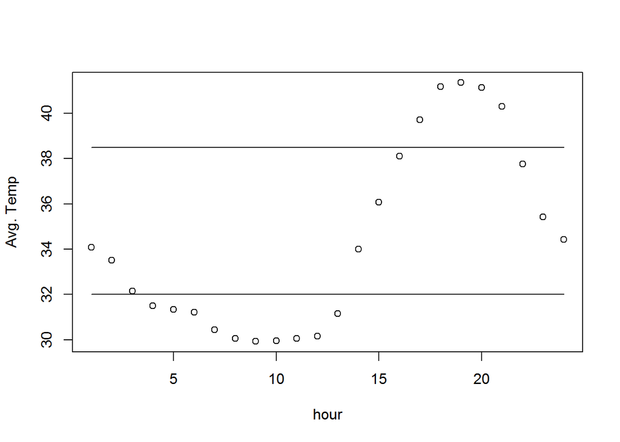

```r
# FROM THE PLOT AND HEATMAP, I CHOOSE MY INTERVALS AS, (1). HOUR 6-12. (2). HOUR 1-5, 13-15, 23, 24. (3). HOUR 16-22
cl15_7 = subset(fall15, hour>=6 & hour<=12)
cl15_8 = subset(fall15, hour <=5 | (hour>=14 & hour<=15) | hour==23 | hour==24)
cl15_9 = subset(fall15, hour>=16 & hour<=22)

# WINTER SEASON ANALYSIS
temp_winter = aggregate(winter15$temp, by = list(hour=winter15$hour), FUN = mean)
plot(temp_winter,ylab = "Avg. Temp")
lines(1:24,rep(32,24))
lines(1:24,rep(38.5,24))
```

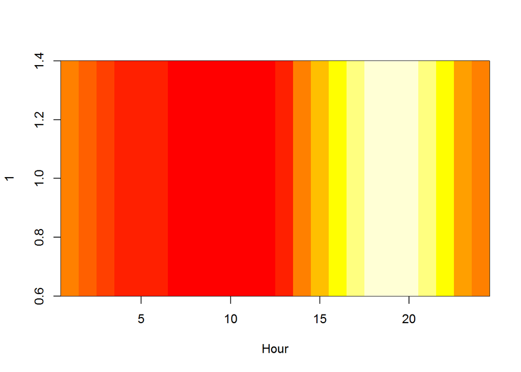

```r
image(1:24,1, matrix(temp_winter[,2]), xlab= "Hour")
```

FROM THE PLOT AND HEATMAP, I CHOOSE MY INTERVALS AS, (1). HOUR 4-13. (2). HOUR 1-3, 14-16, 22-24. (3). HOUR 17-21.

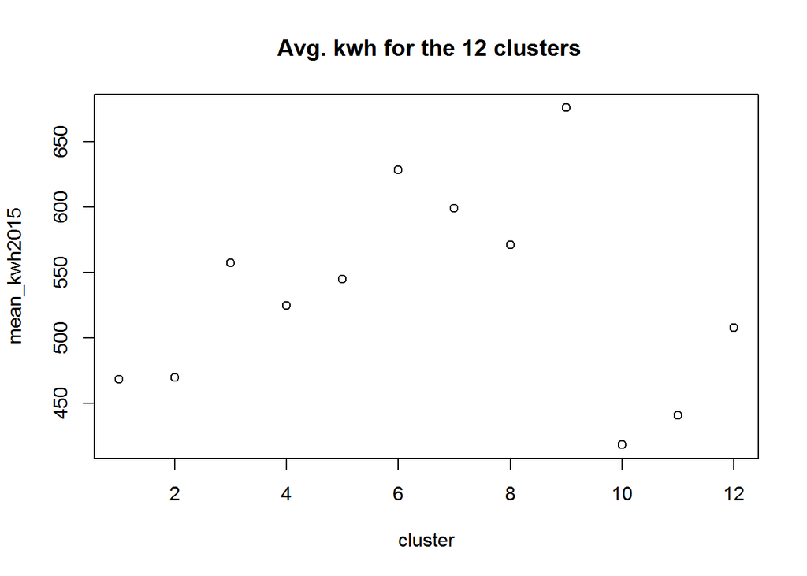

```r
# FROM THE PLOT AND HEATMAP, I CHOOSE MY INTERVALS AS, (1). HOUR 4-13. (2). HOUR 1-3, 14-16, 22-24. (3). HOUR 17-21.
cl15_10 = subset(winter15, hour>=4 & hour<=13)
cl15_11 = subset(winter15, (hour>=1 & hour<=3) | (hour>=14 & hour<=16) | (hour>=22 & hour<=24))
cl15_12 = subset(winter15, hour>=17 & hour<=21)

mean_kwh2015 = c(mean(cl15_1$kwh), mean(cl15_2$kwh), mean(cl15_3$kwh), mean(cl15_4$kwh), mean(cl15_5$kwh), mean(cl15_6$kwh), mean(cl15_7$kwh), mean(cl15_8$kwh), mean(cl15_9$kwh), mean(cl15_10$kwh), mean(cl15_11$kwh), mean(cl15_12$kwh))

plot(mean_kwh2015, xlab = 'cluster', main = ' Avg. kwh for the 12 clusters')
```

An analysis for this result can be demonstrated by the following plot

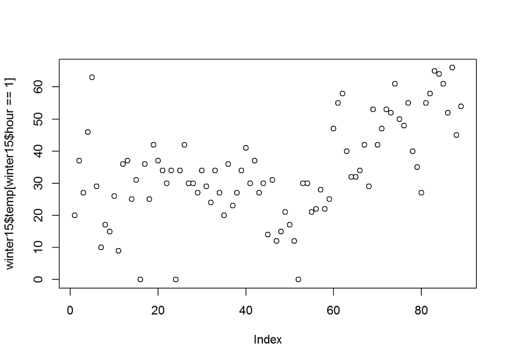

```r
plot(winter15$temp[winter15$hour==1])
```